# Simple graphs/tables

### Birthweight of stillborn babies

```r
 #calculating median BW for stillborn babies, by year
  BW_median_sb <- aggregate(BW ~ birthyear, data = subset(bevn_eco_in3, stillbirth==1), median)
  BW_median_sb
```

```
##    birthyear     BW
## 1       2007 1420.0
## 2       2008 1200.0
## 3       2009 1035.0
## 4       2010  800.0
## 5       2011 1110.0
## 6       2012  760.0
## 7       2013  845.0
## 8       2014 1160.0
## 9       2015 1085.0
## 10      2016 1255.0
## 11      2017 1062.5
## 12      2018  920.0
## 13      2019 1330.0
## 14      2020 1235.0
```

```r
 #calculating mode BW for stillborn babies, by year
  BW_y_mode <- bevn_eco_in3 %>%
   group_by(birthyear) %>%
     filter( !is.na(BW)) %>%
     filter(stillbirth==1) %>%
   summarise(mode=format(getmode(BW), digits=5))
  ungroup(BW_y_mode)
```

```
## # A tibble: 14 x 2
##    birthyear mode
##        <int> <chr>
##  1      2007 1920
##  2      2008 440
##  3      2009 510
##  4      2010 570
##  5      2011 590
##  6      2012 700
##  7      2013 470
##  8      2014 2500
##  9      2015 520
## 10      2016 490
## 11      2017 540
## 12      2018 480
## 13      2019 460
## 14      2020 650
```

```r
  BW_y_mode
```

```
## # A tibble: 14 x 2
##    birthyear mode
##        <int> <chr>
##  1      2007 1920
##  2      2008 440
##  3      2009 510
##  4      2010 570
##  5      2011 590
##  6      2012 700
##  7      2013 470
##  8      2014 2500
##  9      2015 520
## 10      2016 490
## 11      2017 540
## 12      2018 480
## 13      2019 460
## 14      2020 650
```

```r
  #BW frequency for stillbirths, through the years
  BW_SB_Y_freq <- bevn_eco_in3 %>%
   group_by(birthyear) %>%
  filter(stillbirth==1) %>%
   filter(!is.na(BW)) %>%
  select(BW_cat)
  ungroup(BW_SB_Y_freq)
```

```
## # A tibble: 4,276 x 2
##    birthyear BW_cat
##        <int> <fct>
##  1      2007 LBW
##  2      2007 LBW
##  3      2007 LBW
##  4      2007 LBW
##  5      2007 LBW
##  6      2007 LBW
##  7      2007 NBW
##  8      2007 LBW
##  9      2007 LBW
## 10      2007 LBW
## # ... with 4,266 more rows
```

```r
 round(prop.table(table(BW_SB_Y_freq$BW_cat,BW_SB_Y_freq$birthyear), margin=2)*100,2)
```

```
##
##        2007  2008  2009  2010  2011  2012  2013  2014  2015  2016  2017  2018  2019  2020
##   LBW 69.96 74.14 74.17 78.72 74.27 77.35 79.42 75.08 77.92 73.23 79.09 80.94 73.74 73.79
##   NBW 29.60 25.86 25.83 21.28 25.73 22.65 20.58 24.60 22.08 26.77 20.91 19.06 26.26 26.21
##   HBW  0.45  0.00  0.00  0.00  0.00  0.00  0.00  0.32  0.00  0.00  0.00  0.00  0.00  0.00
```

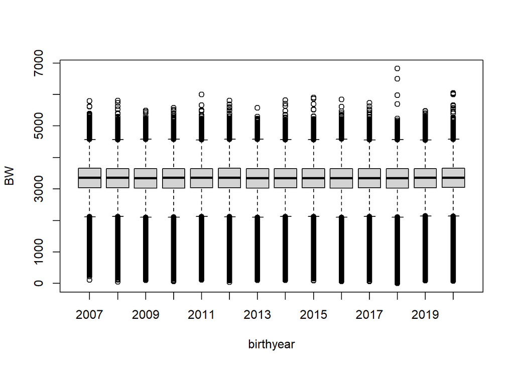

```r
 boxplot(BW~birthyear, data=bevn_eco_in3, subset=BW<8000)
```

Median BW for stillbirths varies a lot through the years, between 760g and 1420g.

## Maternal age through the years

```r
AM_median <- aggregate(mat_age ~ birthyear, data = bevn_eco_in7, median)
AM_median
```

```
##    birthyear mat_age
## 1       2007      31
## 2       2008      31
## 3       2009      31
## 4       2010      31
## 5       2011      31
## 6       2012      31
## 7       2013      31
## 8       2014      31
## 9       2015      32
## 10      2016      32
## 11      2017      32
## 12      2018      32
## 13      2019      32
## 14      2020      32
```

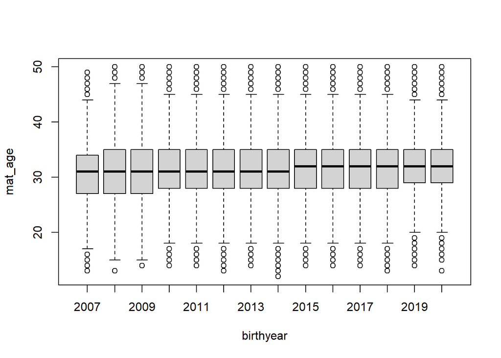

```r
boxplot(mat_age~birthyear, data=bevn_eco_in7)
```

Maternal age increases from 31 to 32 yo between 2006 and 2020.

## Age difference between parents, through the years

```r
summary(bevn_eco_in7$parent_age_diff)
```

```
##    Min. 1st Qu.  Median    Mean 3rd Qu.    Max.    NA's
## -31.000   0.000   2.000   3.028   5.000  54.000   16010
```

```r
agediff_y <- aggregate(parent_age_diff ~ birthyear, data = bevn_eco_in7, median)
agediff_y
```

```
##    birthyear parent_age_diff
## 1       2007               3
## 2       2008               2
## 3       2009               2
## 4       2010               2
## 5       2011               2
## 6       2012               2
## 7       2013               2
## 8       2014               2
## 9       2015               2
## 10      2016               2
## 11      2017               2
## 12      2018               2
## 13      2019               2
## 14      2020               2
```

## Time variables

I created two variables for date : one combining month+year only, and another combining day+month+year. I set up day to 1st of each month in order to have variable m-d-y, easier to work with.

```r
#month year
  tail(bevn_eco_in7$birthdate3)
```

```
## [1] 2020-12 2020-12 2020-12 2020-12 2020-12 2020-12
## 168 Levels: 2007-01 2007-02 2007-03 2007-04 2007-05 2007-06 2007-07 2007-08 2007-09 2007-10 ... 2020-12
```

```r
  head(bevn_eco_in7$birthdate3)
```

```
## [1] 2007-01 2007-01 2007-01 2007-01 2007-01 2007-01
## 168 Levels: 2007-01 2007-02 2007-03 2007-04 2007-05 2007-06 2007-07 2007-08 2007-09 2007-10 ... 2020-12
```

```r
  #day month year
  summary(bevn_eco_in7$birthdate2)
```

```
##         Min.      1st Qu.       Median         Mean      3rd Qu.         Max.
## "2007-01-01" "2010-11-01" "2014-05-01" "2014-03-21" "2017-09-01" "2020-12-01"
```

```r
  tail(bevn_eco_in7$birthdate2)
```

```
## [1] "2020-12-01" "2020-12-01" "2020-12-01" "2020-12-01" "2020-12-01" "2020-12-01"
```

```r
  head(bevn_eco_in7$birthdate2)
```

```
## [1] "2007-01-01" "2007-01-01" "2007-01-01" "2007-01-01" "2007-01-01" "2007-01-01"
```

# Simple plots